# Assignment 2

Fundamental Techniques in Data Science with R

Judith van der Wolf (4661672) Jesse Nieuwkoop (1689959) Bas Bouwhuijzen (2130616) Jay de Jager (6990703)

06-01-2025

# Introduction

For the second assignment we chose a new dataset that will hopefully give us better regression results. We are using a dataset called Customer Behavior from Kaggle. The data represents details about 400 clients of a company including the unique ID, the gender, the age of the customer, the salary, and the information regarding the buying decision - whether the customer decided to buy specific products or not. This dataset contains data on a new unknown product as part of a market assessment. We have a target variable `purchased` with values 0 or 1 (respectively no, and yes) indicating if the product was purchased by the customer. The other variables are `gender`, `age`, and `estimated_salary`. We will use these to predict whether the product was purchased. The `gender` variable has two values in our dataset: male and female. The `age` variable is a continuous numeric value. The `estimated_salary` is a value filled in by the customer with increments of 1000.

## Research Question

“What variables are the best predictors to whether the product was purchased or not?”

# Preperation

## Libraries

```r
library(tidyverse)    # For data manipulation
```

```r
library(ggplot2)      # For plotting
library(ggpubr)       # For ggplot grid arrange
library(kableExtra)   # For fancy tables
library(lmtest)       # Assumption Checks
library(regclass)     # Assumption Checks
library(caret)        # Assumption Checks
```

## Read data

```r
# Read data
data <- read.csv("Customer_Behaviour.csv")

# View data structure
dplyr::glimpse(data)
```

```
## Rows: 400
## Columns: 5
## $ User.ID         <int> 15624510, 15810944, 15668575, 15603246, 15804002, 1572…
## $ Gender          <chr> "Male", "Male", "Female", "Female", "Male", "Male", "F…
## $ Age             <int> 19, 35, 26, 27, 19, 27, 27, 32, 25, 35, 26, 26, 20, 32…
## $ EstimatedSalary <int> 19000, 20000, 43000, 57000, 76000, 58000, 84000, 15000…
## $ Purchased       <int> 0, 0, 0, 0, 0, 0, 0, 1, 0, 0, 0, 0, 0, 0, 0, 0, 1, 1, …
```

# Preprocessing

## Rename

```r
# Rename column names to snake_case format
data <- data %>%
  dplyr::rename(
    user_id = User.ID,
    gender = Gender,
    age = Age,
    estimated_salary = EstimatedSalary,
    purchased = Purchased
  )
```

## Duplicates

The data was checked for duplicates in user_id, because each used_id number should be unique in the dataset. Zero duplicates were found, thus no recards were removed.

```r
# Show count of duplicates
sum(duplicated(data$user_id))
```

```
## [1] 0
```

## Missing values

The data was checked for missing values. No missing values were present.

```r
# Show count of NA values
data %>%
  dplyr::summarise(across(everything(), ~ sum(is.na(.)))) %>%
  tidyr::pivot_longer(
    cols = everything(),
    names_to = "Variable",
    values_to = "NA Count"
  )
```

| Variable | NA Count |
| --- | --- |
| user_id | 0 |
| gender | 0 |
| age | 0 |
| estimated_salary | 0 |
| purchased | 0 |

## Convert to factor

The categorical variables (`gender` and `purchased`) were converted to factor data types.

```r
# Convert variables to factor types
data <- data %>%
  dplyr::mutate(
    gender = as.factor(gender),
    purchased = factor(purchased, levels = c(0, 1), labels = c("No", "Yes"))
  )
```

```r
# View new structure
str(data$gender)
```

```
##  Factor w/ 2 levels "Female","Male": 2 2 1 1 2 2 1 1 2 1 ...
```

```r
str(data$purchased)
```

```
##  Factor w/ 2 levels "No","Yes": 1 1 1 1 1 1 1 2 1 1 ...
```

```r
# Show category distribution
table(data$gender)
```

```
##
## Female   Male
##    204    196
```

```r
table(data$purchased)
```

```
##
##  No Yes
## 257 143
```

## Variable inspection

### Functions

#### capitalize_str()

A function was created to reformat object names to fancy string formatting when creating tables or plots.

```r
# Function to format column name to spaced, capitalized string
capitalize_str <- function(string) {
  # Replace underscores with spaces and capitalize each word
  formatted_name <- gsub("_", " ", string)
  formatted_name <- tools::toTitleCase(formatted_name)

  # Return result
  return(formatted_name)
}
```

#### summary_table_cat()

A function was created to efficiently display the value distribution of categorical variables.

```r
# Function to display comparison summary table
summary_table_cat <- function(data1, data2 = NULL, variable, sort = "none") {
  # Summarize data1
  summary_data1 <- data1 %>%
    group_by(across(all_of(variable))) %>%
    summarise(
      `Frequency (Before)` = n(),
      `Percentage (Before)` = (n() / nrow(data1)) * 100
    )

  if (!is.null(data2)) {
    # Summarize data2 if provided
    summary_data2 <- data2 %>%
      group_by(across(all_of(variable))) %>%
      summarise(
        `Frequency (After)` = n(),
        `Percentage (After)` = (n() / nrow(data2)) * 100
      )

    # Merge summaries
    result <- full_join(summary_data1, summary_data2, by = variable) %>%
      mutate(
        `Percentage (Before)` = sprintf("%.2f%%", `Percentage (Before)`),
        `Percentage (After)` = sprintf("%.2f%%", `Percentage (After)`)
      )

    # Apply sorting
    if (sort == "asc") {
      result <- result %>% arrange(`Frequency (Before)`)
    } else if (sort == "desc") {
      result <- result %>% arrange(desc(`Frequency (Before)`))
    }
  } else {
    # For single dataset case
    result <- summary_data1 %>%
      mutate(
        `Percentage (Before)` = sprintf("%.2f%%", `Percentage (Before)`)
      ) %>%
      rename(`Frequency` = `Frequency (Before)`,
             `Percentage` = `Percentage (Before)`)

    # Apply sorting
    if (sort == "asc") {
      result <- result %>% arrange(Frequency)
    } else if (sort == "desc") {
      result <- result %>% arrange(desc(Frequency))
    }
  }

  # Rename the variable column
  result <- result %>%
    rename(!!capitalize_str(variable) := all_of(variable))

  # Display table
  result <- result %>%
    kbl() %>%
    kable_classic() %>%
    kable_styling(latex_options = c("striped"), full_width = F)

  # Return table
  return(result)
}
```

#### summary_table_nums()

A function was created to efficiently display the summary descriptives of a dataset and its given continuous variables.

```r
# Create function to create summary table for numerical variables
summary_table_nums <- function(data, variables) {
  # Compile summary table
  summary <- data.frame(
    Mean = sapply(variables, function(var) round(mean(data[[var]]), 3)),
    Min = sapply(variables, function(var) min(data[[var]])),
    Median = sapply(variables, function(var) median(data[[var]])),
    Max = sapply(variables, function(var) max(data[[var]])),
    SD = sapply(variables, function(var) round(sd(data[[var]]), 3))
  )

  # Temporarily rename rownames using capitalize_str
  rownames(summary) <- sapply(variables, capitalize_str)

  # Display summary table
  summary <- summary %>%
    kbl() %>%
    kable_classic(latex_options = c("striped"), full_width = TRUE)

  # Return table
  return(summary)
}
```

#### plot_histogram()

A function was created to easily plot the distribution of a given continuous variable in a histogram.

```r
# Function to create a histogram
plot_histogram <- function(data, variable, title = NULL, binwidth = NULL, bins = NULL) {

  # Compile plot
  plot <- ggplot(data, aes(x = .data[[variable]])) +
    geom_histogram(binwidth = binwidth,
                   bins = bins,
                   fill = "lightblue",
                   color = "black") +
    labs(
      title = title,
      x = capitalize_str(variable),
      y = "Frequency",
      fill = variable
    ) +
    theme_bw()

  # Return plot
  return(plot)
}
```

### Categorical variables

#### 1. gender

```r
# Verify structure of factors
str(data$gender)
```

```
##  Factor w/ 2 levels "Female","Male": 2 2 1 1 2 2 1 1 2 1 ...
```

```r
# Verify levels of factors
levels(data$gender)
```

```
## [1] "Female" "Male"
```

```r
# Show summary table
(v1_table <- summary_table_cat(data,
                               variable = "gender")
)
```

| Gender | Frequency | Percentage |
| --- | --- | --- |
| Female | 204 | 51.00% |
| Male | 196 | 49.00% |

##### Table of value frequency for gender

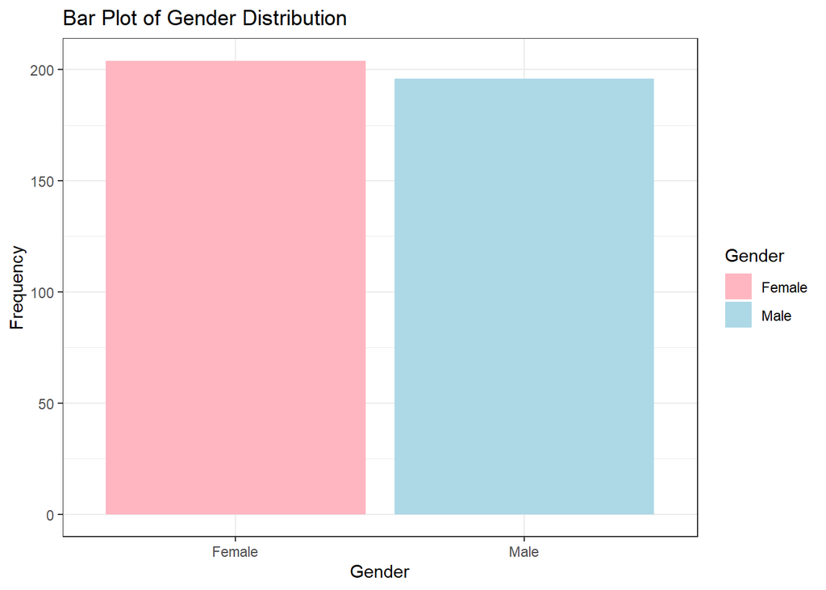

```r
# Show bar plot
(v1_plot <- ggplot(data) +
  geom_bar(aes(x = gender, fill = gender)) +
  scale_fill_manual(values = c("Male" = "lightblue",
                               "Female" = "lightpink")) +
  labs(title = "Bar Plot of Gender Distribution",
       fill = "Gender",
       x = "Gender",
       y = "Frequency"
      ) +
  theme_bw()
)
```

#### 2. purchased

```r
# Verify structure of factors
str(data$purchased)
```

```
##  Factor w/ 2 levels "No","Yes": 1 1 1 1 1 1 1 2 1 1 ...
```

```r
# Verify levels of factors
levels(data$purchased)
```

```
## [1] "No"  "Yes"
```

```r
# Show summary table
(v2_table <- summary_table_cat(data,
                               variable = "purchased")
)
```

| Purchased | Frequency | Percentage |
| --- | --- | --- |
| No | 257 | 64.25% |
| Yes | 143 | 35.75% |

##### Table of value frequency for purchased

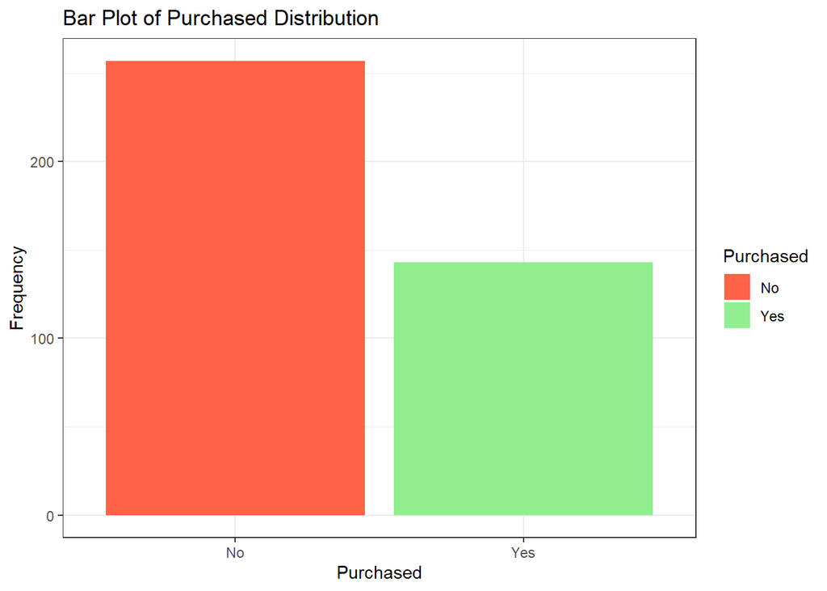

```r
# Show bar plot
(v2_plot <- ggplot(data) +
  geom_bar(aes(x = purchased, fill = purchased)) +
  scale_fill_manual(values = c("No" = "tomato",
                               "Yes" = "lightgreen")) +
  labs(title = "Bar Plot of Purchased Distribution",
       fill = "Purchased",
       x = "Purchased",
       y = "Frequency"
      ) +
  theme_bw()
)
```

### Continuous variables

#### Table of summary descriptives for continuous variables

```r
summary_table_nums(data, c("age",
                               "estimated_salary")
                   )
```

|  | Mean | Min | Median | Max | SD |
| --- | --- | --- | --- | --- | --- |
| Age | 37.655 | 18 | 37 | 60 | 10.483 |
| Estimated Salary | 69742.500 | 15000 | 70000 | 150000 | 34096.960 |

#### 3. age

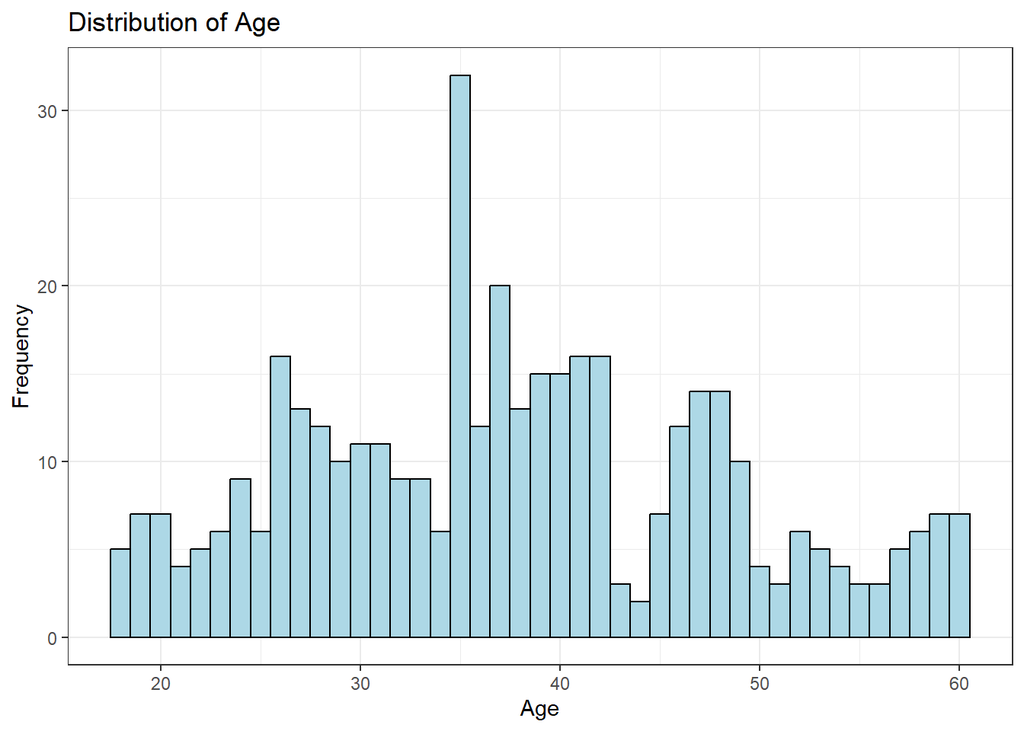

```r
# Plot histogram
(v3_plot <- plot_histogram(data,
                           "age",
                           "Distribution of Age",
                            binwidth = 1)
)
```

#### 4. estimated_salary

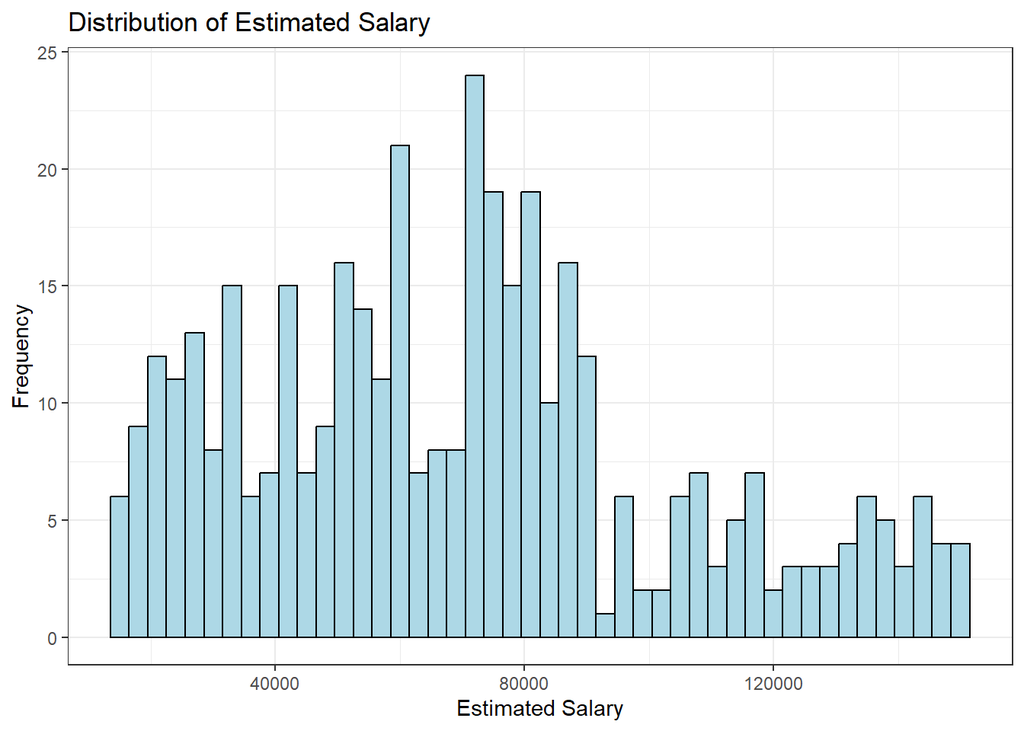

```r
# Plot histogram
(v4_plot <- plot_histogram(data,
                           "estimated_salary",
                           "Distribution of Estimated Salary",
                            binwidth = 3000)
)
```

### General description

After plotting all the predictor variables there were no unrealistic or unnatural values discovered. Furthermore, there were also no (theoretical) outliers present in the dataset. Since the dataset we are working with was flagged as ‘clean’, this was expected. This means that the dataset did not have to be modified in any way to be able to continue performing logistic regression.

# Logistic Regression

## Functions

### compare_models()

A function was created to efficiently compare fit measures across logistic (or linear) models.

```r
# Function to compare fit measures of multiple models
compare_models <- function(data, response_var, compare_with_first = FALSE, model_type = "lm", ...) {
  # Capture models and their names
  models <- list(...)
  model_names <- as.character(substitute(list(...)))[-1] # Extract model names
  num_models <- length(models)

  # Initialize variables to store results
  aic_vals <- numeric(num_models)
  bic_vals <- numeric(num_models)
  mse_vals <- if (model_type == "lm") numeric(num_models) else NULL
  r_squared <- if (model_type == "lm") numeric(num_models) else NULL
  deviance_rss <- c(NA, rep(NA, num_models - 1))
  deviance_pvalue <- c(NA, rep(NA, num_models - 1))

  # Loop through models to compute fit measures
  for (i in seq_along(models)) {
    aic_vals[i] <- AIC(models[[i]])
    bic_vals[i] <- BIC(models[[i]])

    if (model_type == "lm") {
      mse_vals[i] <- mean(models[[i]]$residuals^2)
      r_squared[i] <- summary(models[[i]])$r.squared
    }

    # Perform ANOVA for model comparison
    if (i > 1) {
      if (compare_with_first) {
        base_model <- models[[1]]
      } else {
        base_model <- models[[i - 1]]
      }
      anova_test <- anova(base_model, models[[i]], test = ifelse(model_type == "glm", "Chisq", NULL))
      deviance_rss[i] <- if (model_type == "glm") anova_test$Deviance[2] else anova_test$RSS[2]
      deviance_pvalue[i] <- anova_test$`Pr(>Chi)`[2]
    }
  }

  # Compile results into a tibble
  fit_measures <- tibble(
    Model = capitalize_str(model_names),
    AIC = aic_vals,
    BIC = bic_vals
  )

  # Add R^2 and MSE for linear regression models
  if (model_type == "lm") {
    fit_measures <- fit_measures %>%
      mutate(
        MSE = mse_vals,
        `R^2` = round(r_squared, 3)
      )
  }

  # Add deviance for both model types
  fit_measures <- fit_measures %>%
  mutate(
    `Dev. RSS` = deviance_rss,
    `Dev. p-value` = deviance_pvalue
  )

  # Fancy kable formatting
  fit_measures <- fit_measures %>%
    kbl() %>%
    kable_classic(latex_options = c("striped"), full_width = TRUE)

  # Return fit measures
  return(fit_measures)
}
```

## Models

### Null model

```r
# Define the null model
model_null <- glm(purchased ~ 1,
                  data = data,
                  family = binomial)
summary(model_null)
```

```
##
## Call:
## glm(formula = purchased ~ 1, family = binomial, data = data)
##
## Coefficients:
##             Estimate Std. Error z value Pr(>|z|)
## (Intercept)  -0.5862     0.1043  -5.619 1.92e-08 ***
## ---
## Signif. codes:  0 '***' 0.001 '**' 0.01 '*' 0.05 '.' 0.1 ' ' 1
##
## (Dispersion parameter for binomial family taken to be 1)
##
##     Null deviance: 521.57  on 399  degrees of freedom
## Residual deviance: 521.57  on 399  degrees of freedom
## AIC: 523.57
##
## Number of Fisher Scoring iterations: 4
```

Null model intercept of -0.5862 converts to 35.75% purchasing probability. Found by converting the exponential of the log-odds to statistical odds. As it is the null model, highly significant and strong prediction with outcome.

### Model 1: gender

```r
# Logistic regression with Gender as the sole predictor
model_1 <- glm(purchased ~
                 gender,
               data = data,
               family = binomial)
summary(model_1)
```

```
##
## Call:
## glm(formula = purchased ~ gender, family = binomial, data = data)
##
## Coefficients:
##             Estimate Std. Error z value Pr(>|z|)
## (Intercept)  -0.5004     0.1444  -3.464 0.000531 ***
## genderMale   -0.1775     0.2091  -0.849 0.395858
## ---
## Signif. codes:  0 '***' 0.001 '**' 0.01 '*' 0.05 '.' 0.1 ' ' 1
##
## (Dispersion parameter for binomial family taken to be 1)
##
##     Null deviance: 521.57  on 399  degrees of freedom
## Residual deviance: 520.85  on 398  degrees of freedom
## AIC: 524.85
##
## Number of Fisher Scoring iterations: 4
```

For GenderMale, the “Male” category, the coefficent is -0.1775. Being male reduces the log-odds of purchasing by 0.1775. Lower probability of purchasing compared to being female. The P-value is 0.395858, which is not statistically significant. Therefore Gender does not significantly affect the purchasing probability in this model.

Model Fit:

The AIC is 1 point higher than the null model’s AIC, which suggests it is a worse model in terms of fit + complexity. The slightly lower residual deviance does not outweigh the penalty for adding the extra parameter.

### Model 2: gender + age

```r
# Logistic regression with Gender and Age as predictors
model_2 <- glm(purchased ~
                 gender +
                 age,
               data = data,
               family = binomial)
summary(model_2)
```

```
##
## Call:
## glm(formula = purchased ~ gender + age, family = binomial, data = data)
##
## Coefficients:
##             Estimate Std. Error z value Pr(>|z|)
## (Intercept) -8.11537    0.81377  -9.973   <2e-16 ***
## genderMale   0.09468    0.27354   0.346    0.729
## age          0.18954    0.01926   9.842   <2e-16 ***
## ---
## Signif. codes:  0 '***' 0.001 '**' 0.01 '*' 0.05 '.' 0.1 ' ' 1
##
## (Dispersion parameter for binomial family taken to be 1)
##
##     Null deviance: 521.57  on 399  degrees of freedom
## Residual deviance: 336.14  on 397  degrees of freedom
## AIC: 342.14
##
## Number of Fisher Scoring iterations: 5
```

Intercept of -8.11537, low probability of purchase, when age is 0. The z and p values determine the intercept to be highly statistically significant.

GenderMale indicates that being male increases the log-odds of purchasing by 0.09468 compared to females, holding Age constant. However, this effect is not statistically significant.

The coefficient for Age indicates that each one-unit increase in age increases the log-odds of purchasing by 0.18954, holding Gender constant. Older individuals are much more likely to purchase. For each additional year of age, the odds increase approximately by e^0.18954 ≈1.21 (a 21% increase in odds per year of age). Highly significant.

Much lower residual deviance (336.14) indicates better fit. Suggests age greatly improves model fit.

The AIC is much lower than both the null model (523.57) and Model 1 (524.85).

The addition of Age significantly improves the model’s explanatory power while justifying the slight increase in complexity by 1 parameter.

### Model 3: gender + age + estimated_salary

```r
# Logistic regression with all predictors
model_3 <- glm(purchased ~
                 gender +
                 age +
                 estimated_salary,
               data = data,
               family = binomial)
summary(model_3)
```

```
##
## Call:
## glm(formula = purchased ~ gender + age + estimated_salary, family = binomial,
##     data = data)
##
## Coefficients:
##                    Estimate Std. Error z value Pr(>|z|)
## (Intercept)      -1.278e+01  1.359e+00  -9.405  < 2e-16 ***
## genderMale        3.338e-01  3.052e-01   1.094    0.274
## age               2.370e-01  2.638e-02   8.984  < 2e-16 ***
## estimated_salary  3.644e-05  5.473e-06   6.659 2.77e-11 ***
## ---
## Signif. codes:  0 '***' 0.001 '**' 0.01 '*' 0.05 '.' 0.1 ' ' 1
##
## (Dispersion parameter for binomial family taken to be 1)
##
##     Null deviance: 521.57  on 399  degrees of freedom
## Residual deviance: 275.84  on 396  degrees of freedom
## AIC: 283.84
##
## Number of Fisher Scoring iterations: 6
```

Intercept is at -12.78, when all predictors are at baseline (Gender is Female, Age and EstimatedSalary are both 0). Highly statistically significant, according to the p and z values.

The coefficient for GenderMale suggests that being male increases the log-odds of purchase by 0.3338, while Age and EstimatedSalary remain constant. However, it is a small effect and not statistically significant (p-value: 0.274).

Each increase of age by 1 unit increases the log-odds of purchase by 0.2370, holding Gender and Estimated Salary constant. This corresponds to an increase of 27% in odds for each additional year of age. Age is highly statistically significant.

The coefficient for EstimatedSalary suggests that for every unit increase in salary, the log-odds of purchase increase by 0.00003644, while Gender and Age remain constant. This is statistically significant. This effect seems small, but do not forget that it applies to every single unit of currency.

The residual deviance has dropped significantly compared to all other models. Indicating that EstimatedSalary provides great improvement in model fit.

### Model 4: age + estimated_salary * gender

The results indicate EstimatedSalary to increase the log-odds of purchase significantly. In model 4 it was checked whether this effect was moderated by Gender.

```r
model_4 <- glm(purchased ~
                 age +
                 estimated_salary * gender,
               data = data,
               family = binomial)

summary(model_4)
```

```
##
## Call:
## glm(formula = purchased ~ age + estimated_salary * gender, family = binomial,
##     data = data)
##
## Coefficients:
##                               Estimate Std. Error z value Pr(>|z|)
## (Intercept)                 -1.262e+01  1.388e+00  -9.097  < 2e-16 ***
## age                          2.369e-01  2.635e-02   8.990  < 2e-16 ***
## estimated_salary             3.431e-05  6.825e-06   5.028 4.97e-07 ***
## genderMale                  -7.252e-03  7.387e-01  -0.010    0.992
## estimated_salary:genderMale  4.758e-06  9.385e-06   0.507    0.612
## ---
## Signif. codes:  0 '***' 0.001 '**' 0.01 '*' 0.05 '.' 0.1 ' ' 1
##
## (Dispersion parameter for binomial family taken to be 1)
##
##     Null deviance: 521.57  on 399  degrees of freedom
## Residual deviance: 275.59  on 395  degrees of freedom
## AIC: 285.59
##
## Number of Fisher Scoring iterations: 6
```

The results show a non-significant interaction effect, indicating that the effect of EstimatedSalary on the log-odds of purchase is consistent across levels of Gender.

### Comparing Model Fit

Model 3 is the best fit, with a significantly lower AIC value. The addition of Age and EstimatedSalary significantly improves the model fit.

```r
# Comparing model to null model
compare_models(data,
              "purchased",
              FALSE,
              "glm",
              model_null,
              model_1,
              model_2,
              model_3,
              model_4)
```

| Model | AIC | BIC | Dev. RSS | Dev. p-value |
| --- | --- | --- | --- | --- |
| Model Null | 523.5730 | 527.5644 | NA | NA |
| Model 1 | 524.8510 | 532.8339 | 0.7219999 | 0.3954887 |
| Model 2 | 342.1413 | 354.1157 | 184.7096593 | 0.0000000 |
| Model 3 | 283.8432 | 299.8091 | 60.2980813 | 0.0000000 |
| Model 4 | 285.5855 | 305.5429 | 0.2576916 | 0.6117105 |

## Assumptions

### Sufficient sample size

```r
# Show sample size
(sample_size <- nrow(data))
```

```
## [1] 400
```

```r
# Calculate proportion of purchased
(purchased <- data %>%
  count(purchased) %>%
  mutate(prop = n / sum(n)))
```

| purchased | n | prop |
| --- | --- | --- |
| No | 257 | 0.6425 |
| Yes | 143 | 0.3575 |

```r
# Return smallest proportion of negative or positive cases.
(p <- min(purchased$prop))
```

```
## [1] 0.3575
```

```r
# Return number of predictors (k) of final model
(k <- length(coef(model_3)))
```

```
## [1] 4
```

```r
# Calculate the minimum number of cases (n)
(n <- ceiling((10 * k) / p))
```

```
## [1] 112
```

```r
# Check if sample size is sufficient
if (sample_size > n) {
  result <- "Sample size is sufficient"
} else {
  result <- "Sample size is not sufficient"
}

# Add values
result <- paste0(result, " (Samplze size = ", sample_size, ", minimum cases = ", n, ").")

# Print result
print(result)
```

```
## [1] "Sample size is sufficient (Samplze size = 400, minimum cases = 112)."
```

### Multicollinearity

Predictor matrix is full-rank.

```r
# Retrieve VIF values
vif_values <- car::vif(model_3)

# Force the output into a GVIF-like structure
gvif_table <- tibble(
  Variable = capitalize_str(names(vif_values)),
  VIF = vif_values,
  df = 1,
  GVIF = (vif_values^(1 / (1 + df)))
)

# Fancy kable table formatting
gvif_table %>%
  kbl() %>%
  kable_classic(latex_options = c("striped"), full_width = TRUE)
```

| Variable | VIF | df | GVIF |
| --- | --- | --- | --- |
| Gender | 1.027105 | 1 | 1.013462 |
| Age | 1.400914 | 1 | 1.183602 |
| Estimated Salary | 1.385439 | 1 | 1.177047 |

### Linearity

```r
data$logit <- predict(model_3, type = "link")
```

As can be seen, the linearity of age to log odds is relatively constant, Which means that age has a relatively consistent influence on the log odds of purchasing.

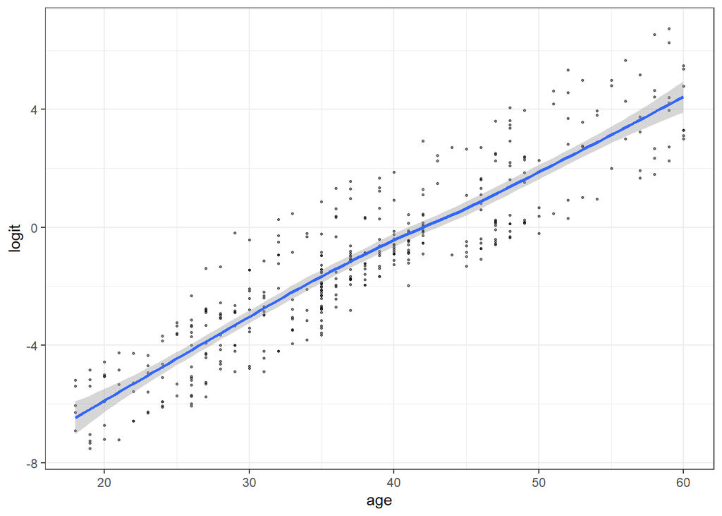

```r
data %>%
ggplot(aes(age, logit))+
  geom_point(size = 0.5, alpha = 0.5) +
  geom_smooth(method = "loess") +
  theme_bw()
```

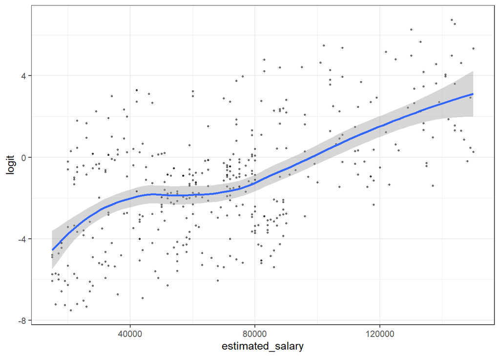

```r
data %>%
ggplot(aes(estimated_salary, logit))+
  geom_point(size = 0.5, alpha = 0.5) +
  geom_smooth(method = "loess") +
  theme_bw()
```

As can be seen, there are no points that fall outside of the the dashed lines (Cook’s distance), hence there are no outliers that are influential. These would need to be treated or reported.

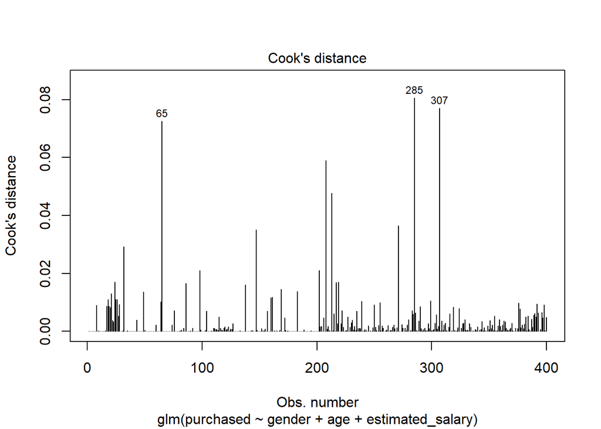

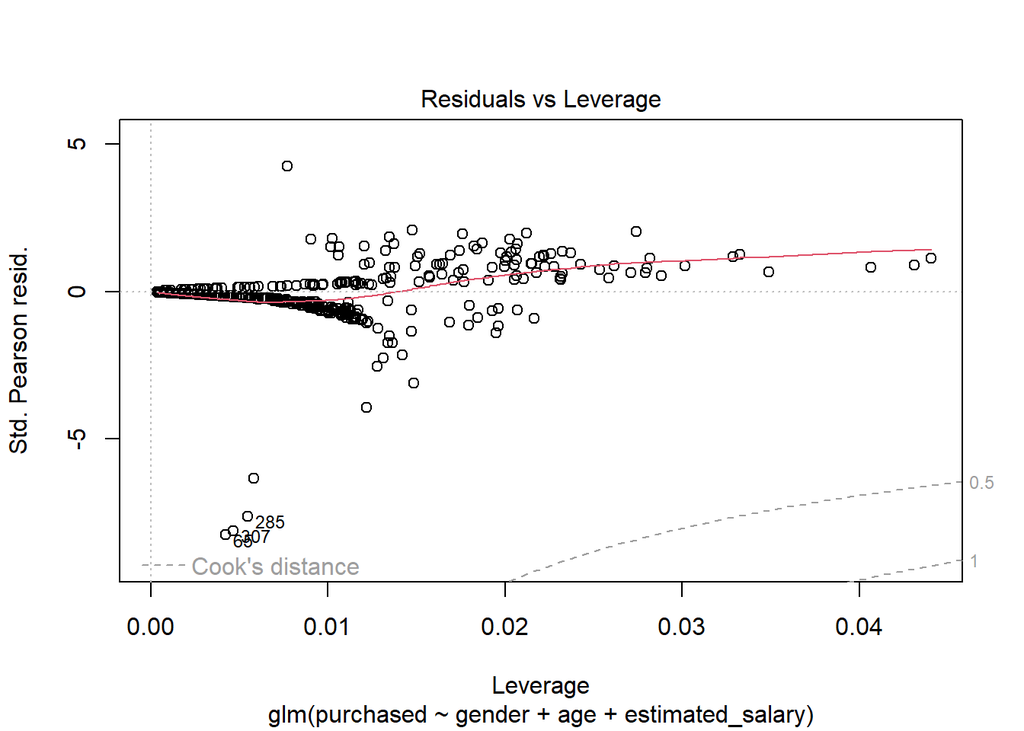

```r
plot(model_3, which = c(4,5))
```

### Binomially distribution

The outcome is independently and identically binomially distributed. The bar plot shows there are two outcomes for purchased, so the outcome meets the outcome of a binomial distribution. 257 participants did not buy the product and 143 did.

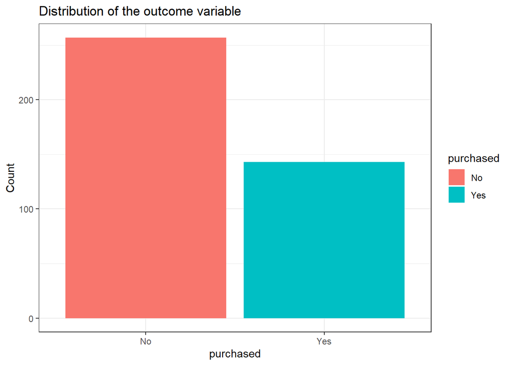

```r
data %>%
  ggplot(aes(x = purchased, fill = purchased)) +
  geom_bar() +
  labs(x = "purchased",
       y = "Count",
       title = "Distribution of the outcome variable") +
  theme_bw()
```

```r
levels(data$purchased)
```

```
## [1] "No"  "Yes"
```

```r
table(data$purchased)
```

```
##
##  No Yes
## 257 143
```

### Residual Clustering.

We didn’t expect residual clustering, because the only variables in the dataset are whether or not a product is purchased, gender and people’s estimated salary. There is no reason to believe that there were other variables that could have influenced the variation among the groups, at least no other variables that were measured.

# Predicted probabilities

```r
data <- data %>%
  mutate(piHat = predict(model_3, type = "response"),
    yHat = as.factor(ifelse(piHat <= 0.5, "No", "Yes"))
  )
```

```r
cMat <- confusionMatrix(data = data$yHat, reference = data$purchased)
cMat$table
```

```
##           Reference
## Prediction  No Yes
##        No  237  39
##        Yes  20 104
```

```r
cMat$overall
```

```
##       Accuracy          Kappa  AccuracyLower  AccuracyUpper   AccuracyNull
##   8.525000e-01   6.691712e-01   8.138982e-01   8.857819e-01   6.425000e-01
## AccuracyPValue  McnemarPValue
##   5.146453e-21   1.910886e-02
```

```r
cMat$byClass
```

```
##          Sensitivity          Specificity       Pos Pred Value
##            0.9221790            0.7272727            0.8586957
##       Neg Pred Value            Precision               Recall
##            0.8387097            0.8586957            0.9221790
##                   F1           Prevalence       Detection Rate
##            0.8893058            0.6425000            0.5925000
## Detection Prevalence    Balanced Accuracy
##            0.6900000            0.8247259
```

1. Accuracy (0.8525 or 85.25%)

   Interpretation: The model correctly predicted the outcome (yes/no) 85.25% of the time. This is a good accuracy score, suggesting that the model performs well on the dataset. Comparison to Null Accuracy (0.6425 or 64.25%): The model’s accuracy is significantly higher than the null accuracy (baseline accuracy if always predicting the majority class), indicating that the model adds substantial predictive value.
2. Kappa (0.669 or 66.9%)

   Interpretation: Kappa measures agreement between predicted and actual values, adjusted for chance. A value of 0.66 is considered substantial agreement, suggesting a strong, reliable model. Generally: < 0.20: Poor 0.21–0.40: Fair 0.41–0.60: Moderate 0.61–0.80: Substantial 0.81–1.00: Almost perfect
3. Sensitivity (0.9222 or 92.22%)

   Interpretation: This is the average of sensitivity and specificity, accounting for class imbalance. It confirms the overall good performance.
8. McNemar’s Test p-value (0.019 or 1.9%)

   Interpretation: This tests if there’s a significant difference in the prediction errors between the two classes. A low p-value (< 0.05) suggests that the model’s errors are significantly biased, indicating a potential need for further evaluation or adjustments.